# Fractal Hack Approach | Saurav Kaushik

Sarav Kaushik

July 4, 2017

This is the approach for 4th place solution on Fractal Analytics Hackathon on Analytics Vidhya submitted by Saurav Kaushik. I used R statistical programming language for solving this problem statement.

**Problem statement:**

*Welcome to Antallagma - a digital exchange for trading goods. Antallagma started its operations 5 years back and has supported more than a million transactions till date. The Antallagma platform enables working of a traditional exchange on an online portal.

On one hand, buyers make a bid at the value they are willing to buy (“bid value”) and the quantity they are willing to buy. Sellers on the other hand, ask for an ask price and the quantity they are willing to sell. The portal matches the buyers and sellers in realtime to create trades. All trades are settled at the end of the day at the median price of all agreed trades.

You are one of the traders on the exchange and can supply all the material being traded on the exchange. In order to improve your logistics, you want to predict the median trade prices and volumes for all the trades happening (at item level) on the exchange. You can then plan to then use these predictions to create an optimized inventory strategy.

You are expected to create trade forecasts for all items being traded on Antallagma along with the trade prices for a period of 6 months. *

So, Being a supplier, we need to predict two things, the median trade prices and volumes of each item traded using machine learning. The behaviour of each item of buyers/ sellers can make significant predictors if captured properly. This can be translated into bidding/trading systems. Let’s now have a look at my solution.

The solution consists of the following 10 sections:

- Loading data and libraries.
- Data Cleaning.
- Feature Engineering.
- Exploratory Data Analysis.
- Modelling.
- Feature Importance.
- Post processing.
- What worked and what didn’t.
- Ideas not tried becaus of time shortage.
- Closing comments

**1. Loading data and libraries.**

```r
#Loading required libraries
library(caret)
library(xgboost)
library(dplyr)
```

```r
library(ggplot2)


#Reading train n test
train<-read.csv("train.csv")
test<-read.csv("test.csv")

sample_sub<-read.csv("Sample_Submission_Zxs5Ys1.csv")

#Structure of data
str(train)
```

```
## 'data.frame':    881876 obs. of  8 variables:
##  $ ID             : Factor w/ 881876 levels "29654_20160617",..: 428990 363754 174166 623169 581156 659074 863720 450865 165854 203328 ...
##  $ Item_ID        : int  30495 30375 30011 30864 30780 30927 31342 30540 29999 30068 ...
##  $ Datetime       : Factor w/ 912 levels "2014-01-01","2014-01-02",..: 1 1 1 1 1 1 1 1 1 1 ...
##  $ Category_3     : int  0 0 0 0 1 0 0 0 0 0 ...
##  $ Category_2     : num  2 2 3 2 2 1 2 3 3 2 ...
##  $ Category_1     : int  90 307 67 315 132 38 38 38 67 195 ...
##  $ Price          : num  165.1 68.7 253.3 223.1 28.8 ...
##  $ Number_Of_Sales: int  1 5 2 1 1 402 832 423 133 375 ...
```

**2. Data Cleaning.**

```r
#Correcting data types

train$Category_1<-as.numeric(train$Category_1)
test$Category_1<-as.numeric(test$Category_1)

train$Category_2<-as.numeric(train$Category_2)
test$Category_2<-as.numeric(test$Category_2)

train$Category_3<-as.factor(train$Category_3)
test$Category_3<-as.factor(test$Category_3)

train$Datetime<-as.Date(train$Datetime,"%Y-%m-%d")
test$Datetime<-as.Date(test$Datetime,"%Y-%m-%d")
```

**3. Feature Engineering.**

1. Creating basic date features:

```r
#Creating features

train$year<-as.numeric(format(train$Datetime, "%Y"))
test$year<-as.numeric(format(test$Datetime, "%Y"))

train$month<-as.numeric(format(train$Datetime, "%m"))
test$month<-as.numeric(format(test$Datetime, "%m"))

train$day<-as.numeric(format(train$Datetime, "%d"))
test$day<-as.numeric(format(test$Datetime, "%d"))

train$weekday<-as.factor(weekdays(train$Datetime))
test$weekday<-as.factor(weekdays(test$Datetime))
```

```r
train_features<-as.data.frame(train %>%
                                group_by(Item_ID) %>%
                                summarise(sum_price_n = sum(Price)/ log(1+length(Price)), mean_price = mean(Price), median_price = median(Price), sd_price = sd(Price), nprice = length(Price),
                                          nsales_price_n = sum(Number_Of_Sales)/ log(1+length(Number_Of_Sales)), mean_nsales = mean(Number_Of_Sales), median_nsales = median(Number_Of_Sales), sd_nsales = sd(Number_Of_Sales), nsales_id = length(Number_Of_Sales)))

test_features<-as.data.frame(test %>%
                                group_by(Item_ID) %>%
                               summarise(nprice_2 = length(Item_ID),
                                          nsales_id_2 = length(Item_ID)))


train_new<-merge(train,train_features,by = "Item_ID")

test_new<-merge(test,train_features,by = "Item_ID")

train_new2<-merge(train_new,test_features,by = "Item_ID")

test_new3<-merge(test_new,test_features,by = "Item_ID")

train_new2$Datetime<-NULL
test_new3$Datetime<-NULL
```

**4. Exploratory Data Analysis.**

Let’s see the univaraite distribution of the outcomes:

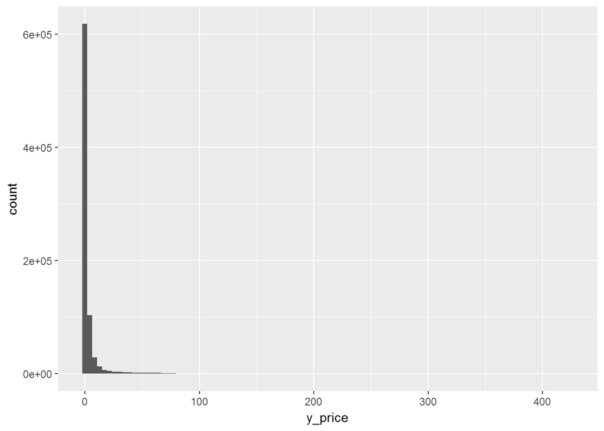

```r
y_price<-train_new2$Price

qplot(y_price, bins = 100)
```

High right skew, let’s check out the second outcome, number of sales:

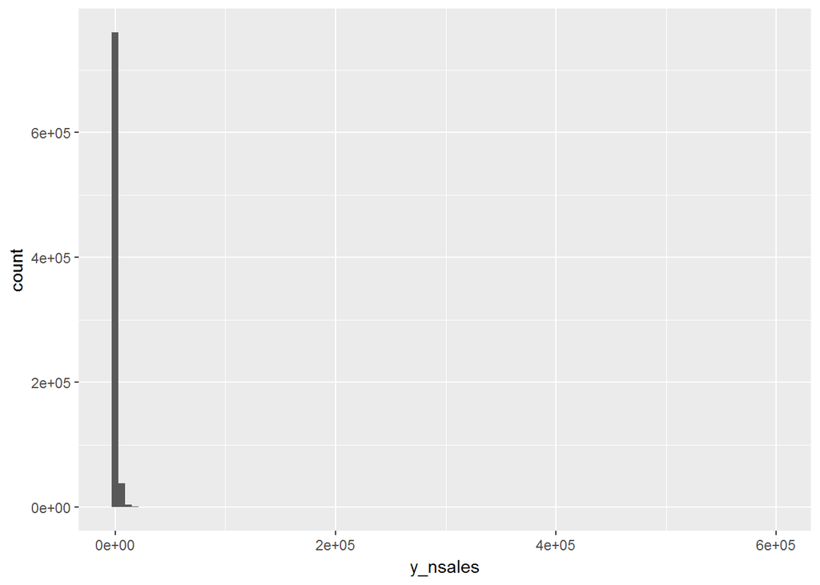

```r
y_nsales<-train_new2$Number_Of_Sales

qplot(y_nsales, bins = 100)
```

Again, high right skew. Let’s take the log(1+x) transformation of the outcomes to get them close to normal distribution.

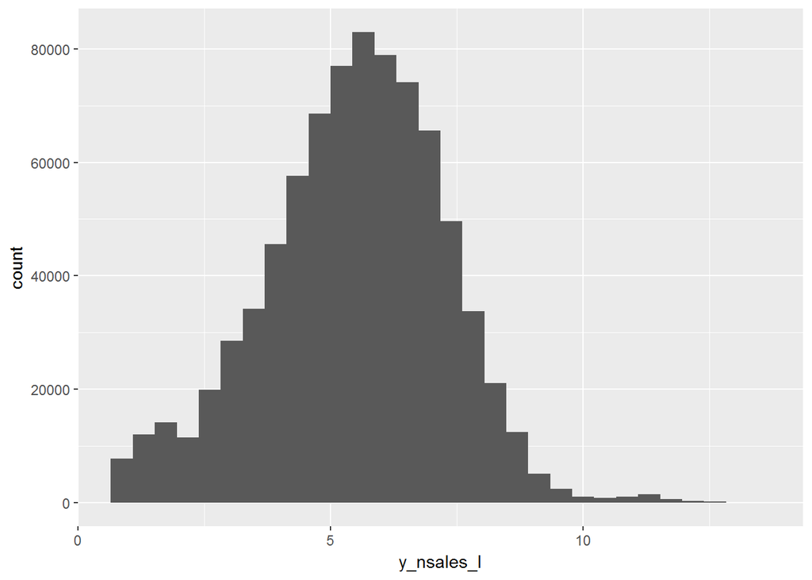

```r
y_price_l<-log(y_price+1)
y_nsales_l<-log(y_nsales+1)

qplot(y_nsales_l, bins = 30)
```

Looks much better now. Let’s further explore the bivariates.

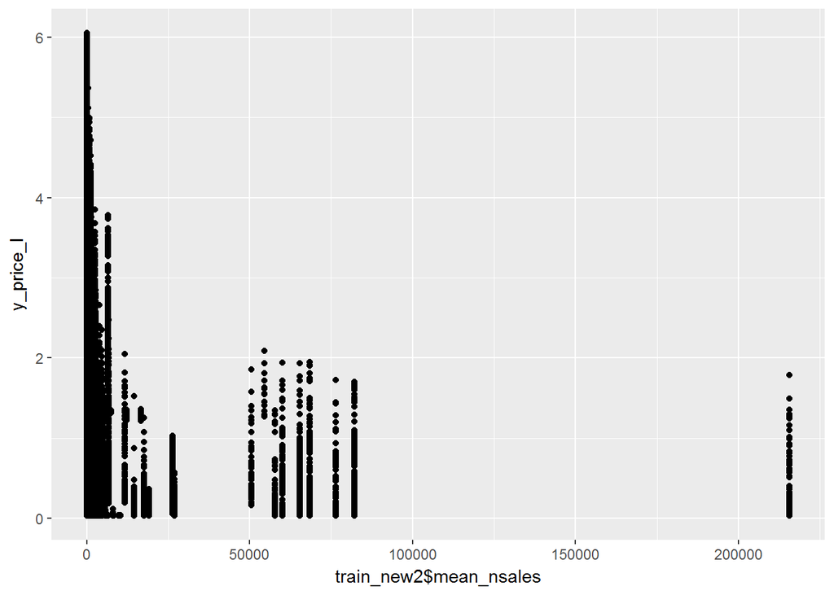

```r
train_new2$Price<-NULL
train_new2$Number_Of_Sales<-NULL

test_item_id<-test_new3$Item_ID
test_id<-test_new3$ID

train_new2$Item_ID<-NULL
test_new3$Item_ID<-NULL

train_new2$ID<-NULL
test_new3$ID<-NULL

qplot(x = train_new2$mean_nsales, y = y_price_l)
```

Relationship between mean sales and log transformation of price outcome looks preety non-linear.

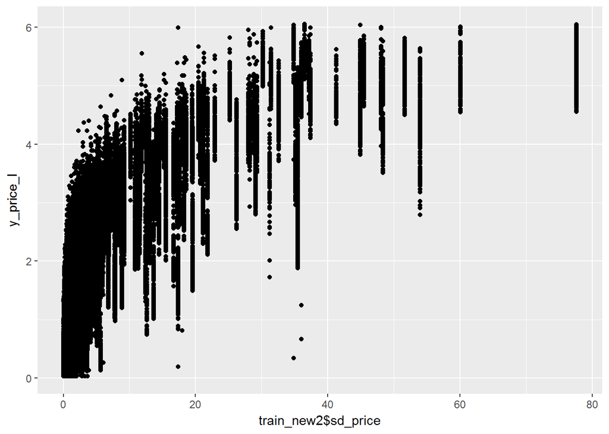

```r
qplot(x = train_new2$sd_price, y = y_price_l)
```

Relationship between standard deviation and log transformation of price outcome looks preety non-linear as well.

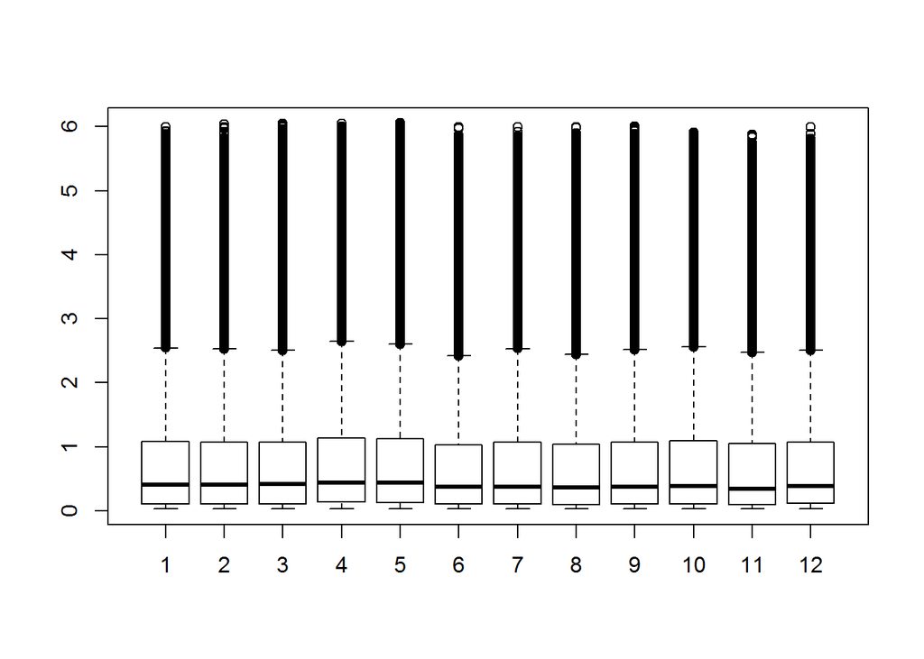

```r
plot(as.factor(train_new2$month),y_price_l)
```

Simmilarly, after studying the relationship of the outcome varaible with several other independent features, I took a decesion to go for non-linear tree based models. In the end I did tried using linear model which gave very poor performance. Because of massive size of dataset, superiority over other tree-based models and relatively faster training time, I used XGBoost for this competetion.

**5. Modelling.**

Preparing the data for modelling. Using On-hot encoding. Also, taking lof(1+x) transformation of the outcome features as they were relatively well normally distributed.

```r
dmy <- dummyVars(" ~ .", data = train_new2, fullRank = F)
x_train <- data.frame(predict(dmy, newdata = train_new2))

dmy <- dummyVars(" ~ .", data = test_new3, fullRank = F)
x_test <- data.frame(predict(dmy, newdata = test_new3))


x_train$mean_price_l<-log(1+x_train$mean_price)
x_train$mean_nsales_l<-log(1+x_train$mean_nsales)

x_test$mean_price_l<-log(1+x_test$mean_price)
x_test$mean_nsales_l<-log(1+x_test$mean_nsales)

x_train$sd_price_l<-log(1+x_train$sd_price)
x_train$sd_nsales_l<-log(1+x_train$sd_nsales)

x_test$sd_price_l<-log(1+x_test$sd_price)
x_test$sd_nsales_l<-log(1+x_test$sd_nsales)
```

After running a few iterations and removing a few least significant predictors from the model, I ended up using the following predictors:

```r
predictors<-c("Category_3.1", "Category_2", "Category_1",
              "year", "month",
              "mean_price_l", "mean_nsales_l", "sd_price_l", "sd_nsales_l")


#Convering to dense matrix
dtrain_price <- xgb.DMatrix(data=as.matrix(x_train[,predictors]), label=y_price_l)
dtrain_sales <- xgb.DMatrix(data=as.matrix(x_train[,predictors]), label=y_nsales_l)

dtest <- xgb.DMatrix(data=as.matrix(x_test[,predictors]))
```

For validation, I tried time based validation and random 10-fold cross calidation. Randon CV gave me a better sync, therefore, I sticked with random cv rather than time-based validation. I needed not to treat missing values which exixt only in catogory_2 feature as xgboost figures out to treat the missing values with a few possiblities like imputing with mean, 0, median, etc and picks the best one based on cv.

```r
#Setting seed for reproducibility
set.seed(1)

#watchlist <- list(train=dtrain, validation=dval)

#Model parameters for predicting price.
param <- list(
  objective = "reg:linear",
  eval_metric = "rmse",
  eta = 0.3,
  max_depth = 2
)

#Random 10-fold cV for predicting price.
cv_price <- xgb.cv(
  params = param,
  data = dtrain_price,
  nrounds = 10000,
#  watchlist = watchlist,
  nfold = 10,
  maximize = F,
  early_stopping_rounds = 20,
  print_every_n = 50
)


#Model parameters for predicting num sales.
param2 <- list(
  objective = "reg:linear",
  eval_metric = "rmse",
  eta = 0.3,
  #  lambda = 2
  max_depth = 2
)


#Random 10-fold cV for predicting num sales.
cv_sales <- xgb.cv(
  params = param2,
  data = dtrain_sales,
  nrounds = 10000,
  nfold = 10,
  print_every_n  = 20
)
```

Now, Training the two xgboost models for two outcomes.

```r
#Model parameters for predicting price.
param <- list(
  objective = "reg:linear",
  eval_metric = "rmse",
  eta = 0.3,
  max_depth = 2
)

xgb_price <- xgb.train(
  params = param,
  data = dtrain_price,
  nrounds = 1500
  )



#Model parameters for predicting num sales.
param2 <- list(
  objective = "reg:linear",
  eval_metric = "rmse",
  eta = 0.3,
  #  lambda = 2
  max_depth = 2
)

xgb_nsales <- xgb.train(
  params = param2,
  data = dtrain_sales,
  nrounds = 900
  )
```

**6. Feature Importance.**

The following is the feature importance plot for the price model:

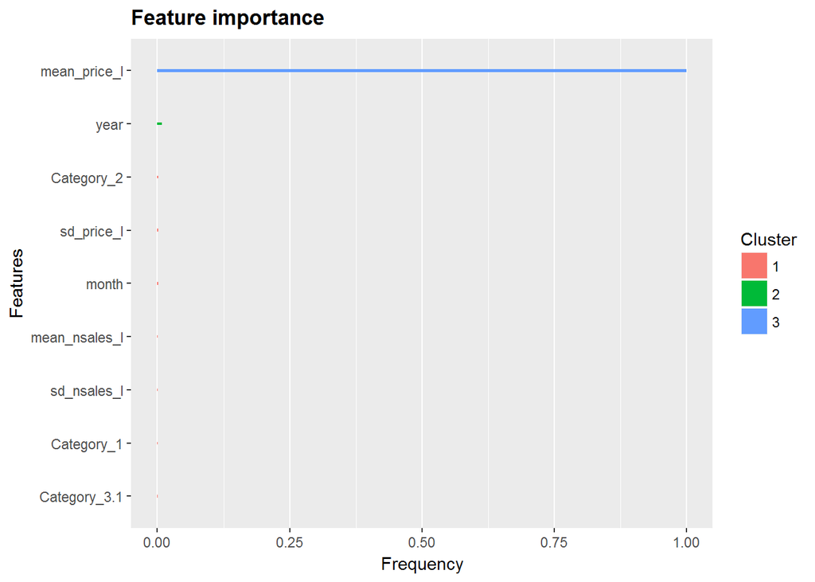

```r
gg <- xgb.ggplot.importance(xgb.importance(model = xgb_price,feature_names =  predictors), measure = "Gain", rel_to_first = TRUE)
gg + ggplot2::ylab("Frequency")
```

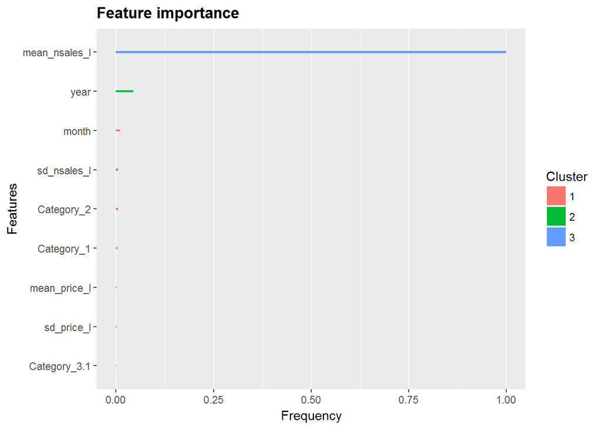

```r
gg <- xgb.ggplot.importance(xgb.importance(model = xgb_nsales,feature_names =  predictors), measure = "Gain", rel_to_first = TRUE)
gg + ggplot2::ylab("Frequency")
```

**7. Post Processing**

Just the last bit to make sure that we do not go out-of-bounds with our predictions. So, ensuring the lowest bound for predictions is only 0.

```r
y_pred_price<-exp(predict(object = xgb_price,newdata = dtest))-1
y_pred_nsales<-exp(predict(object = xgb_nsales,newdata = dtest))-1

y_pred_price[y_pred_price<0]<-0
y_pred_nsales[y_pred_nsales<0]<-0

sub<-data.frame(ID = test_id, Number_Of_Sales = y_pred_nsales, Price = y_pred_price)

#Final submission
#Public LB Rank: 5
#Private LB Rank: 4
write.csv(sub, "sub16_without_weekdays.csv", row.names = F)
```

Also, here’s the code for the linear model which I didn’t used becasue of poor performance as was expected from the EDA section.

```r
#Linear model

tr<-x_train[,predictors]
te<-x_test[,predictors]


for(i in 1:ncol(tr))
{
  if(is.numeric(tr[,i]))
  {
    tr[is.na(tr[,i]),i]<-as.numeric(median(tr[,i], na.rm = TRUE))
  }

}

for(i in 1:ncol(te))
{
  if(is.numeric(te[,i]))
  {
    te[is.na(te[,i]),i]<-as.numeric(median(te[,i], na.rm = TRUE))
  }

}



tr$y_price_l<-y_price_l
tr$y_nsales_l<-y_nsales_l

model_price = lm(y_price_l ~ ., data = tr[,predictors])
model_sales = lm(y_nsales_l ~ ., data = tr[,predictors])

y_pred_price<-exp(predict(object = model_price,newdata = te))-1
y_pred_nsales<-exp(predict(object = model_sales,newdata = te))-1

y_pred_price[y_pred_price<0]<-0
y_pred_nsales[y_pred_nsales<0]<-0

sub<-data.frame(ID = test_id, Number_Of_Sales = y_pred_nsales, Price = y_pred_price)

#Did not used the linear model
#write.csv(sub, "sub14_with_mean_sd_both_log_plus_one_linear.csv", row.names = F)
```

**9. Ideas not tried because of time shortage.**

I almost started this competetion after half-time and simontanously was also participating in another machine learning competetion which was ending at the same time. Therefore, below is a lit of things that I would have liked to try given more time.

1. Using filter methods for feature seletion.
2. A bit more of parameter tuning.
3. Ensembeling using varied models.
4. Using ML for imputing missing vales existing in Category_2.
5. Using different set of features for both models.

**10. Closing comments**

It was certainly a challanging time-series problem in which the past behaviour of Item_ID acted as really significant predictor for the outcomes. Even though we were missing the real context of the problem which could have lead to better feature engineering with the masked catogories, but it still proved to be a significant test of building first iterations of machinne leanrinig model for a business problem translated to a data problem.

*Lastly, I’ll like to thank you for this wonderful opportunity. It was a really interesting real-world dataset. For my codes in various other data science competitions and datasets, please view my GitHub profile and published articles from the links below. Thank you!*

[GitHub](https://github.com/sauravkaushik8) [Articles](https://www.analyticsvidhya.com/blog/author/sauravkaushik8/)